# Single-cell RNA-seq

## 10.7 Differential detection

- Pseudobulk DE analyses test for changes in the mean expression.
- However, the distribution of the gene expression can also change in other aspects.
- With the low counts of scRNA-seq data, whether a gene is detected in a cell at all is also informative.
- Note, that methods exists for assessing differential distributions, i.e. differences in location and shape.
- Here, we will focus on one specific modality, i.e. differential detection.

Gilis et al. (2025) show that changes in the average fraction of cells in which a gene is detected (**differential detection**, DD) provide information that is complementary to DE.

**Data**: we binarise the counts ($z_{gi} = 1$ if $y_{gi} > 0$) and sum them per sample: $Z_{gs} = \sum_{i \in s} z_{gi}$ is the number of cells of sample $s$ in which gene $g$ is detected, out of $n_s$ cells. We do not have to compute this ourselves: `aggregateAcrossCells.se` stores $Z_{gs}$ in the assay `detected` of the pseudobulk object `pb`, next to the summed counts (assay `sums`) that we used for DE. DE and DD thus start from the same pseudobulk samples, but summarise the cells differently: the total number of UMIs versus the number of cells with at least one UMI.

**Model**: the same NB GLM with the edgeR QL pipeline,

$$\log \text{E}[Z_{gs}] = \mathbf{x}_s^\top \boldsymbol\beta_g + \log(n_s \, \text{CDR}_s),$$

- The offset contains the number of cells $n_s$: we model the fraction of cells in which the gene is detected, as the library size in the DE analysis.
- $\text{CDR}_s$ is the cellular detection rate of the sample: the average fraction of cells in which a gene is detected. It corrects for global differences in detection, e.g. due to the sequencing depth, as the normalisation factors in the DE analysis.
- Genes detected in (almost) all cells carry no information on detection: genes with a median detection fraction of 0.9 or more over the samples are removed.
- The binarised counts are bounded by $n_s$, so they can be underdispersed with respect to the Poisson distribution: the QL test is performed with `poisson.bound = FALSE`.

This is the workflow `edgeR_NB_optim` of Gilis et al. (2025), which performed best in their benchmarks. We use it for the CD14+ monocytes, on the genes of the DE analysis.

```r
selDD <- pb$celltype == "CD14+ Monocytes"
# number of cells of each sample in which each gene is detected
Z <- assay(pb, "detected")[, selDD]
nCells <- pb$ncells[selDD]

deMono <- deResults[["CD14+ Monocytes"]]
detection <- sweep(Z, 2, nCells, "/")
medDetection <- matrixStats::rowMedians(as.matrix(detection[rownames(deMono), ]))
keepDD <- rownames(deMono)[medDetection < 0.9]
cdr <- colMeans(detection[keepDD, ])

yDD <- DGEList(Z[keepDD, ],
               samples = as.data.frame(colData(pb)[selDD, c("patient", "stim", "ncells")]))
yDD$offset <- log(nCells * cdr)
designDD <- model.matrix(~ patient + stim, data = yDD$samples)
yDD <- estimateDisp(yDD, designDD)
fitDD <- glmQLFit(yDD, designDD, robust = TRUE)
ddMono <- glmQLFTest(fitDD, coef = "stimstim", poisson.bound = FALSE)
summary(decideTests(ddMono))
```

```
       stimstim
Down       1828
NotSig      853
Up          910
```

**Stage-wise testing of DE and DD**

With two hypotheses per gene, we control the FDR at the gene level with stage-wise testing:

1. *Screening*: the null hypothesis that neither the mean expression nor the detection changes. We combine the DE and DD p-values with the harmonic mean, $p_g = 2 / (1/p_g^{DE} + 1/p_g^{DD})$, which is also valid for dependent tests (Wilson 2019). Genes that were removed from the DD analysis get their DE p-value.
2. *Confirmation*: the DE and DD hypotheses of the genes that pass the screening. Once the screening null hypothesis is rejected, at most one of the two hypotheses can be true, so Shaffer’s method requires no further correction (`shafferS1(diag(2))` returns `1 1`, `method = "none"`).

```r
pDE <- setNames(deMono$table$PValue, rownames(deMono))
pDD <- setNames(rep(NA, length(pDE)), names(pDE))
pDD[rownames(ddMono)] <- ddMono$table$PValue
pScreen <- ifelse(is.na(pDD), pDE, 2 / (1 / pDE + 1 / pDD))

stageRObj <- stageR(pScreen = pScreen, pConfirmation = cbind(DD = pDD, DE = pDE),
                    pScreenAdjusted = FALSE)
stageRObj <- stageWiseAdjustment(stageRObj, method = "none", alpha = 0.05, allowNA = TRUE)
ddDe <- getResults(stageRObj)
table(DD = ddDe[, "DD"], DE = ddDe[, "DE"])
```

```
   DE
DD     0    1
  0  733  245
  1  420 2253
```

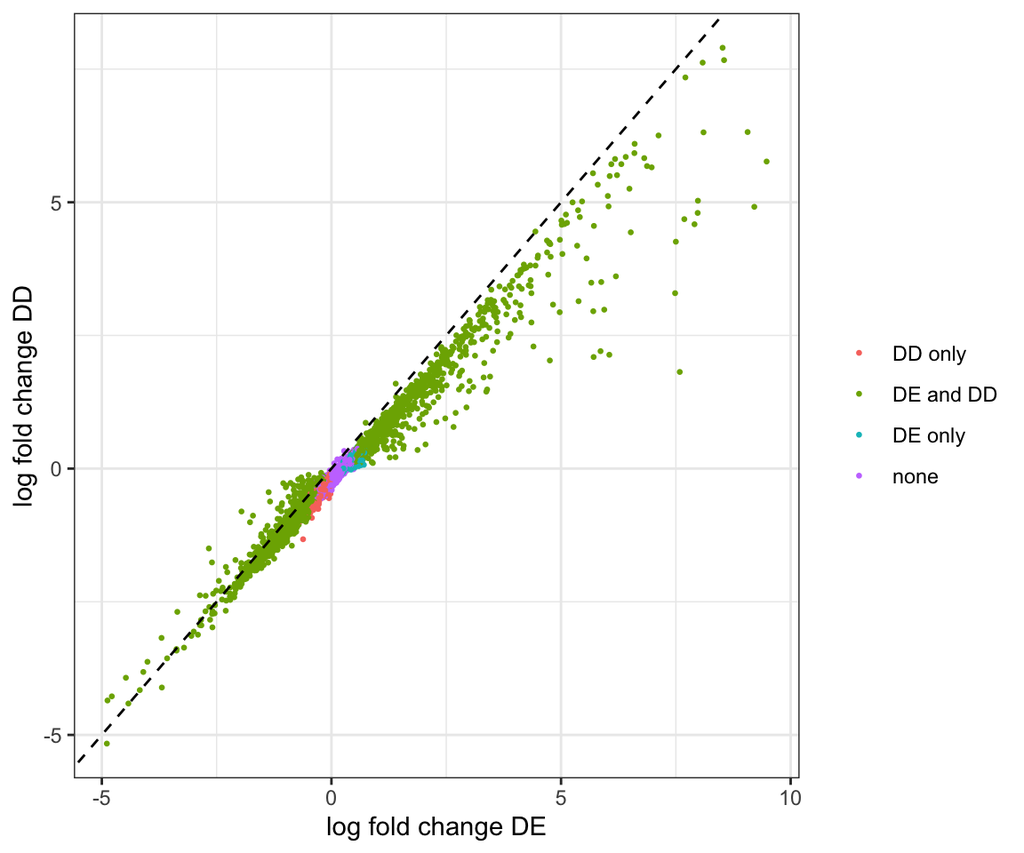

```r
tibble(gene = rownames(ddMono),
       logFC_DE = deMono$table[rownames(ddMono), "logFC"],
       logFC_DD = ddMono$table$logFC,
       DE = ddDe[rownames(ddMono), "DE"] == 1,
       DD = ddDe[rownames(ddMono), "DD"] == 1) |>
  mutate(significant = case_when(DE & DD ~ "DE and DD", DE ~ "DE only",
                                 DD ~ "DD only", TRUE ~ "none")) |>
  ggplot(aes(logFC_DE, logFC_DD, color = significant)) +
  geom_point(size = 0.5) +
  geom_abline(linetype = 2) +
  labs(x = "log fold change DE", y = "log fold change DD", color = "") +
  theme_bw()
```

- The log fold changes of DE and DD are strongly correlated: for most genes, a change in mean expression goes together with a change in detection.
- Still, 420 genes are only found in the DD analysis, and 245 only in the DE analysis: both analyses provide complementary information, and Gilis et al. (2025) recommend to perform both.
- The DD log fold changes are relative to the CDR of the sample, and are interpreted as the change in the detection fraction compared to an average gene.
- The confounding with the run also applies here: e.g. differences in capture efficiency between the runs affect the detection of genes. The CDR offset is one factor per sample: it corrects for differences in detection that affect all genes equally, but not for technical differences that affect genes differently, e.g. because the detection of lowly and highly expressed genes responds differently to the capture efficiency.

**All cell types with muscat**

We analysed DD for one cell type, to show the model. The muscat package (Crowell et al. 2020) implements the same pseudobulk workflows, and performs the DE and DD analyses for all cell types in one call:

- `aggregateData()` sums the counts (`fun = "sum"`) or the binarised counts (`fun = "num.detected"`) per cell type and sample, as the `sums` and `detected` assays of `pb`. The result contains one assay per cell type.
- `pbDS()` performs the pseudobulk DE analysis with the edgeR QL pipeline, and `pbDD()` the DD analysis with the workflow above: the filter on the median detection fraction, the CDR offset, and `poisson.bound = FALSE`. Before that, `pbDD()` filters the genes with `filterByExpr` on the number of detected cells, so it can test a slightly different set of genes than we did. Both fit a separate model for each cell type, and return one table of results per cell type. The p-values are adjusted for multiple testing within each cell type (`p_adj.loc`) and over all cell types together (`p_adj.glb`).
- `stagewise_DS_DD()` combines the DE and DD results of each cell type with the stage-wise test of this section.
- Cell types with too few cells per sample are skipped (argument `min_cells`).

The [DD vignette](https://bioconductor.org/packages/release/bioc/vignettes/muscat/inst/doc/detection.html) of muscat illustrates this on the same Kang data, with the default design `~ group_id`. To block for the patient, as we did, pass a design matrix:

```r
sce <- kang
sce$id <- paste0(sce$stim, sce$patient)
sce <- muscat::prepSCE(sce, kid = "celltype", sid = "id", gid = "stim")
pbSum <- muscat::aggregateData(sce, assay = "counts", fun = "sum")
pbDet <- muscat::aggregateData(sce, assay = "counts", fun = "num.detected")
design <- model.matrix(~ patient + group_id, data = as.data.frame(colData(pbDet)))
resDS <- muscat::pbDS(pbSum, design = design, coef = ncol(design))
resDD <- muscat::pbDD(pbDet, design = design, coef = ncol(design))
resStagewise <- muscat::stagewise_DS_DD(resDS, resDD)
# results for one cell type
resStagewise[[1]][["CD14+ Monocytes"]]
```

## 10.8 Differential abundance

Does the composition of the PBMCs change upon stimulation? We count the cells per cell type and sample, and model these counts with the same NB GLM.

```r
abundances <- table(kang$celltype, interaction(kang$patient, kang$stim, sep = "_"))
abundanceSamples <- tibble(sample = colnames(abundances)) |>
  separate(sample, c("patient", "stim"), sep = "_", remove = FALSE) |>
  mutate(patient = factor(patient), stim = factor(stim, levels = c("ctrl", "stim")))
yDA <- DGEList(unclass(abundances), samples = as.data.frame(abundanceSamples))
designDA <- model.matrix(~ patient + stim, data = yDA$samples)
fitDA <- glmQLFit(yDA, designDA)
topTags(glmQLFTest(fitDA, coef = "stimstim"))$table |>
  knitr::kable(digits = 3)
```

|  | logFC | logCPM | F | PValue | FDR |
| --- | --- | --- | --- | --- | --- |
| NK cells | 0.246 | 16.290 | 11.130 | 0.002 | 0.012 |
| FCGR3A+ Monocytes | 0.187 | 16.041 | 5.444 | 0.023 | 0.093 |
| CD8 T cells | -0.147 | 16.353 | 4.152 | 0.046 | 0.103 |
| CD14+ Monocytes | -0.079 | 17.836 | 3.956 | 0.052 | 0.103 |
| Dendritic cells | 0.126 | 14.253 | 1.151 | 0.288 | 0.461 |
| B cells | -0.051 | 16.596 | 0.638 | 0.428 | 0.570 |
| Megakaryocytes | 0.046 | 13.691 | 0.108 | 0.743 | 0.849 |
| CD4 T cells | 0.000 | 18.640 | 0.000 | 0.992 | 0.992 |

- Only the proportion of NK cells changes significantly, and the fold change is small. The composition of the PBMCs hardly changes between the conditions, as expected after only 6 hours.
- Again, the change in NK cells cannot be attributed to the stimulation: the cell type proportions can also differ between runs, e.g. because cell types differ in how well they survive the sample preparation or are captured in the droplets.
- The library size is the total number of cells of a sample: the model describes the **proportion** of each cell type.
- The proportions are **compositional**: if one cell type increases, the proportions of all other cell types decrease. A change in one cell type therefore shows up as a change in the opposite direction in all other cell types.
- TMM normalisation assumes that most cell types do not change. With only a few cell types this is a strong assumption. Alternatively, TREAT can be used to focus on large changes, which are unlikely to be due to a compositional effect of another cell type.
- Here, the cell types were annotated after the stimulation: the stimulation can change the expression of the marker genes, and thus the labels.
- A large literature exists on addressing compositionality, which is beyond the scope of the course.

# 11 Summary

- Droplet-based scRNA-seq data are low counts with many zeros. After removal of empty droplets, low-quality cells and doublets, they are well described by Poisson and NB models: no zero inflation is needed.
- The concepts of the bulk RNA-seq lectures carry over: offsets for the library size, deviances for feature selection, and GLMs with a low-rank term for dimension reduction (GMF).
- Clustering and marker gene detection are exploratory: the p-values of tests between clusters are not valid, because the data are used twice.
- In multi-sample experiments, the experimental unit is the sample, not the cell. Pseudobulk analyses with the edgeR QL pipeline control the FDR for differential expression between conditions, and allow to block for the individual.
- Differential detection, a pseudobulk analysis of the binarised counts, provides information that is complementary to DE; both can be combined with stage-wise testing.
- The cell counts per cell type and sample can be analysed with the same NB GLMs for differential abundance, keeping their compositional nature in mind.
- Batch effects are removed for exploration (GMF with a batch covariate, or integration methods such as MNN for batch effects that differ between cell types), but modelled for inference (the batch in the pseudobulk design).
- Experimental design remains crucial: multiplexing removes batch effects between individuals, but conditions that are processed in separate runs are confounded with the run. Neither batch correction nor modelling can repair this afterwards.

## References

Agostinis, Federico, Chiara Romualdi, Gabriele Sales, and Davide Risso. 2022. “NewWave: A Scalable R/Bioconductor Package for the Dimensionality Reduction and Batch Effect Removal of Single-Cell RNA-seq Data.” *Bioinformatics* 38 (9): 2648–50. https://doi.org/10.1093/bioinformatics/btac149.

Amezquita, Robert A., Aaron T. L. Lun, Etienne Becht, et al. 2020. “Orchestrating Single-Cell Analysis with Bioconductor.” *Nature Methods* 17: 137–45. https://doi.org/10.1038/s41592-019-0654-x.

Aran, Dvir, Agnieszka P. Looney, Leqian Liu, et al. 2019. “Reference-Based Analysis of Lung Single-Cell Sequencing Reveals a Transitional Profibrotic Macrophage.” *Nature Immunology* 20: 163–72. https://doi.org/10.1038/s41590-018-0276-y.

Bourgon, Richard, Robert Gentleman, and Wolfgang Huber. 2010. “Independent Filtering Increases Detection Power for High-Throughput Experiments.” *Proceedings of the National Academy of Sciences* 107 (21): 9546–51.

Castiglione, Cristian, Alexandre Segers, Lieven Clement, and Davide Risso. 2026. “Stochastic Gradient Descent Estimation of Generalized Matrix Factorization Models with Application to Single-Cell RNA Sequencing Data.” *Biostatistics* 27 (1): kxag010. https://doi.org/10.1093/biostatistics/kxag010.

Collins, Michael, Sanjoy Dasgupta, and Robert E. Schapire. 2001. “A Generalization of Principal Components Analysis to the Exponential Family.” *Advances in Neural Information Processing Systems 14*, 617–24.

Crowell, Helena L., Charlotte Soneson, Pierre-Luc Germain, et al. 2020. “Muscat Detects Subpopulation-Specific State Transitions from Multi-Sample Multi-Condition Single-Cell Transcriptomics Data.” *Nature Communications* 11: 6077. https://doi.org/10.1038/s41467-020-19894-4.

Germain, Pierre-Luc, Aaron Lun, Carlos Garcia Meixide, Will Macnair, and Mark D. Robinson. 2021. “Doublet Identification in Single-Cell Sequencing Data Using scDblFinder.” *F1000Research* 10: 979. https://doi.org/10.12688/f1000research.73600.2.

Gilis, Jeroen, Laura Perin, Milan Malfait, et al. 2025. “Differential Detection Workflows for Multi-Sample Single-Cell RNA-seq Data.” *BMC Genomics* 26: 886. https://doi.org/10.1186/s12864-025-12102-x.

Haghverdi, Laleh, Aaron T. L. Lun, Michael D. Morgan, and John C. Marioni. 2018. “Batch Effects in Single-Cell RNA-Sequencing Data Are Corrected by Matching Mutual Nearest Neighbors.” *Nature Biotechnology* 36: 421–27. https://doi.org/10.1038/nbt.4091.

Junttila, Sini, Johannes Smolander, and Laura L. Elo. 2022. “Benchmarking Methods for Detecting Differential States Between Conditions from Multi-Subject Single-Cell RNA-seq Data.” *Briefings in Bioinformatics* 23 (5): bbac286. https://doi.org/10.1093/bib/bbac286.

Kang, Hyun Min, Meena Subramaniam, Sasha Targ, et al. 2018. “Multiplexed Droplet Single-Cell RNA-Sequencing Using Natural Genetic Variation.” *Nature Biotechnology* 36: 89–94. https://doi.org/10.1038/nbt.4042.

Lause, Jan, Philipp Berens, and Dmitry Kobak. 2021. “Analytic Pearson Residuals for Normalization of Single-Cell RNA-seq UMI Data.” *Genome Biology* 22: 258. https://doi.org/10.1186/s13059-021-02451-7.

Lun, Aaron T. L., Karsten Bach, and John C. Marioni. 2016. “Pooling Across Cells to Normalize Single-Cell RNA Sequencing Data with Many Zero Counts.” *Genome Biology* 17: 75. https://doi.org/10.1186/s13059-016-0947-7.

Lun, Aaron T. L., Samantha Riesenfeld, Tallulah Andrews, et al. 2019. “EmptyDrops: Distinguishing Cells from Empty Droplets in Droplet-Based Single-Cell RNA Sequencing Data.” *Genome Biology* 20: 63. https://doi.org/10.1186/s13059-019-1662-y.

Neufeld, Anna, Lucy L. Gao, Joshua Popp, Alexis Battle, and Daniela Witten. 2024. “Inference After Latent Variable Estimation for Single-Cell RNA Sequencing Data.” *Biostatistics* 25 (1): 270–87. https://doi.org/10.1093/biostatistics/kxac047.

Pijuan-Sala, Blanca, Jonathan A. Griffiths, Carolina Guibentif, et al. 2019. “A Single-Cell Molecular Map of Mouse Gastrulation and Early Organogenesis.” *Nature* 566: 490–95. https://doi.org/10.1038/s41586-019-0933-9.

Risso, Davide, Fanny Perraudeau, Svetlana Gribkova, Sandrine Dudoit, and Jean-Philippe Vert. 2018. “A General and Flexible Method for Signal Extraction from Single-Cell RNA-seq Data.” *Nature Communications* 9: 284. https://doi.org/10.1038/s41467-017-02554-5.

Segers, Alexandre, Cristian Castiglione, Christophe Vanderaa, et al. 2025. “omicsGMF: A Multi-Tool for Dimensionality Reduction, Batch Correction and Imputation Applied to Bulk- and Single Cell Proteomics Data.” *bioRxiv*, March, 2025.03.24.644996.

Squair, Jordan W., Matthieu Gautier, Claudia Kathe, et al. 2021. “Confronting False Discoveries in Single-Cell Differential Expression.” *Nature Communications* 12: 5692. https://doi.org/10.1038/s41467-021-25960-2.

Svensson, Valentine. 2020. “Droplet scRNA-seq Is Not Zero-Inflated.” *Nature Biotechnology* 38: 147–50. https://doi.org/10.1038/s41587-019-0379-5.

Townes, F. William, Stephanie C. Hicks, Martin J. Aryee, and Rafael A. Irizarry. 2019. “Feature Selection and Dimension Reduction for Single-Cell RNA-Seq Based on a Multinomial Model.” *Genome Biology* 20: 295. https://doi.org/10.1186/s13059-019-1861-6.

Wilson, Daniel J. 2019. “The Harmonic Mean p-Value for Combining Dependent Tests.” *Proceedings of the National Academy of Sciences* 116 (4): 1195–200. https://doi.org/10.1073/pnas.1814092116.